# DOM bridges and barriers: systematic review and survey

Author

Emily Nazario | UC Santa Cruz | enazario’@’ucsc.edu

Published

September 20, 2025

## Questions

**Which themes overlap between the literature and surveys?**

**Which themes only appear in the literature? Which themes are unique to the surveys?**

**How do themes vary between fishing vs. shipping contexts?**

**How do themes vary with positionality of the respondent (surveys only)?**

## Result 1: Bridges and barriers according to review and survey

Here I’ve presented three options for presenting the themes and sub-themes identified in the review and surveys. I’d love feedback on which option or combination of options best visualize the codes! Depending on your feedback, I’ll then spend time cleaning up the best option.

### Option 1 - Sankey diagram

Plot below only presents the review themes and sub-themes. If this is the best way to communicate the codes, I will add a diagram visualizing the survey codes.

```
# A tibble: 2 × 2
  bridge_barr totals
  <chr>        <int>
1 Barrier        201
2 Bridge         509
```

```
# A tibble: 6 × 2
  code_cat           totals
  <chr>               <int>
1 Data barrier           86
2 Data bridge           173
3 Ecological barrier     13
4 Ecological bridge     141
5 Social barrier        102
6 Social bridge         195
```

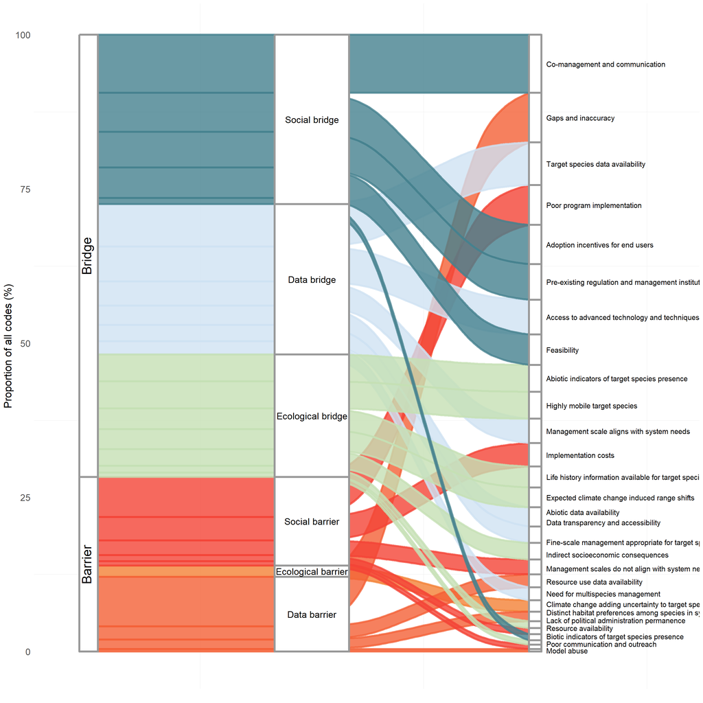

### Option 2 - Sunburst figure

Plots below are from an old draft of the review themes and sub-themes. If this is the nicest way to plot the codes, I will update the diagram and generate one for the survey themes as well.

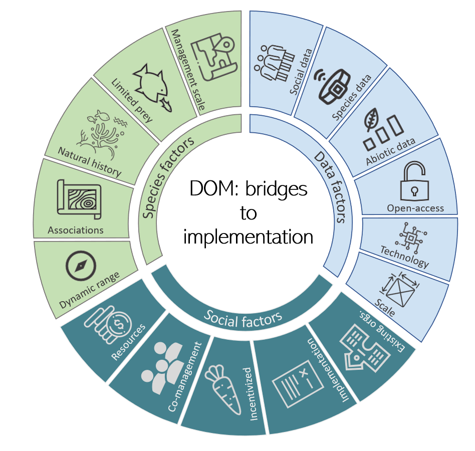

[figure not shown]

### Option 3 - Table

**Review: Bridge themes**

| Code category | Code label |
| --- | --- |
| Data bridge | Management scale aligns with system needs |
| Data bridge | Target species data availability |
| Data bridge | Access to advanced technology and techniques |
| Data bridge | Data transparency |
| Data bridge | Abiotic data availability |
| Data bridge | Resource use data availability |
| Social bridge | Resource availability |
| Social bridge | Pre-existing conditions |
| Social bridge | Adoption incentives |
| Social bridge | Feasibility |
| Social bridge | Co-management and communication |
| Ecological bridge | Expected climate change induced range shifts |
| Ecological bridge | Distinct habitat preferences |
| Ecological bridge | Biotic indicators of target species presence |
| Ecological bridge | Abiotic indicators of target species presence |
| Ecological bridge | Highly mobile target species |
| Ecological bridge | Life history information available for target species |
| Ecological bridge | Fine-scale management appropriate for target species |

**Review: Barrier themes**

| Code category | Code label |
| --- | --- |
| Data barrier | Gaps and inaccuracy |
| Data barrier | Management scales do not align with system needs |
| Data barrier | Model abuse |
| Ecological barrier | Need for multispecies management |
| Data barrier | Climate change adding uncertainty to target species habitat use |
| Social barrier | Indirect socioeconomic consequences |
| Social barrier | Discontinuity |
| Social barrier | Poor communication and outreach |
| Social barrier | Poor program implementation |
| Social barrier | Cost |

**Survey: Bridge themes**

| Code category | Code label |
| --- | --- |
| Implementation bridge | Behavior change |
| Implementation bridge | Regulated program |
| Implementation bridge | Volunteer based program |
| Implementation bridge | Simplicity |
| Implementation bridge | Online presence |
| Implementation bridge | Tailored to user group |
| Implementation bridge | Clear objectives |
| Implementation bridge | Communication mechanisms |
| Social bridge | Fleet buy-in |
| Social bridge | External factors increasing participation |
| Social bridge | Communication and transparency |
| Social bridge | Adoption incentives |
| Social bridge | Observable progress |
| Implementation bridge | Program outreach |
| Social bridge | Co-management |
| Data bridge | Rapid data delivery |
| Ecological bridge | Distinct habitat preferences |
| Ecological bridge | Predictable spatial use |

**Survey: Barrier themes**

| Code category | Code label |
| --- | --- |
| Implementation barrier | Difficulty assessing impact |
| Implementation barrier | Limited relevance |
| Data barrier | Missing cross-program comparisons |
| Data barrier | Gaps and inaccuracy |
| Data barrier | Lack of near real-time data |
| Ecological barrier | Unpredictable bycatch patterns |
| Social barrier | Cost |
| Social barrier | Discontinuity |
| Social barrier | Confidentiality |
| Social barrier | Lack of incentives |
| Social barrier | Volunteer programs reduce participation |
| Social barrier | Regulated programs reduce participation |
| Social barrier | External factors reducing participation |
| Social barrier | Poor communication and outreach |
| Social barrier | Interest-holder conflicts |
| Social barrier | Stigmatization |

## Result 2: Frequencies according to review and survey

**Literature**

Code appearance frequencies across articles (n = 118). The proportions reported in these figures represent the percent of papers that mentioned a subcode within these broader code categories at least once.

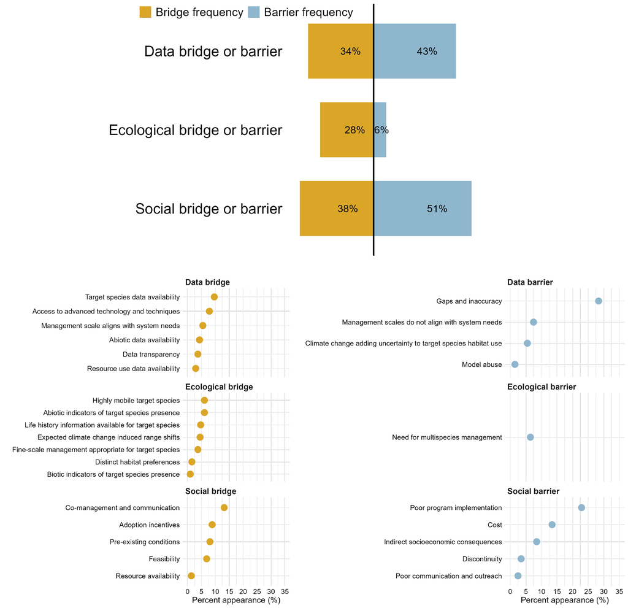